# A Tutorial for the `data.cube` Library

Robin Lamarche-Perrin

June 2019

`data.cube` is an R package for the exploration of multidimensional datasets and for the detection of statistical outliers within. It is mainly a tool for data exploration, allowing to have a first glance at it and to formulate research hypotheses to be later tested.

The package defines a new data structure called `data.cube` that can be fed with a classical `data.frame` encoding a list of numeric observations described according to several categorical dimensions. For example, in the case of Twitter data, it can be the number of tweets (numeric observation) that have been published by a given user (first dimension) about a given topic (second dimension) at a given date (third dimension). The input `data.frame` hence takes the form of a list of quadruplets (user, topic, date, number of tweets).

Statistical outliers can then be identified among the observations by first selecting some dimensions of interest, that is by subsetting or by aggregating the input dimensions. If needed, observations can also be normalised according to the marginal values along the selected dimensions, thus comparing the observed value to an expected value obtained by the uniform redistribution of the selected marginal values. Different statistical tests can then be chosen to measure the deviation between the observed and the expected values. The package finally allows to retrieve a list of positive outliers, that is observations that are significantly higher than expected.

# Table of Contents

- Installation
- Authors and License
- Getting Started
  - Downloading the dataset
  - Loading the library
  - Building the cube with `as.data.cube`
  - What’s in the cube with `summary`
  - Back to frame with `as.data.frame`
- Unidimensional Exploration
  - Selecting one dimension with `select.dim`
  - Arranging elements with `arrange.elm`
  - Plotting variables with `plot.var`
  - Filtering elements with `filter.elm` and `top_n.elm`
  - Other examples of use
- Multidimensional Exploration
  - Selecting two dimensions with `select.dim`
  - Plotting bidimensional variables with argument `sep.dim.names` of `plot.var`
  - Plotting multidimensional variables
- Outlier Analysis
  - First example: Bidimensional outliers
    - Taking into account the average number of articles per country
    - Also taking into account the average number of articles per day

# Installation

The library is available on CRAN:

```r
install.packages ('data.cube')
```

Its source code is available on GitHub: https://github.com/Lamarche-Perrin/data.cube

# Authors and License

This library has been developed by researchers of the [Complex Networks](http://www.complexnetworks.fr/) team, within the [Laboratoire d’informatique de Paris 6](https://www.lip6.fr/), for the [ODYCCEUS](https://www.odycceus.eu/) project, founded by the [European Commission FETPROACT 2016-2017 program](https://ec.europa.eu/research/participants/portal/desktop/en/opportunities/h2020/calls/h2020-fetproact-2016-2017.html) under grant 732942.

Copyright © 2017-2019 Robin Lamarche-Perrin (Robin.Lamarche-Perrin@lip6.fr)

`data.cube` is free software: you can redistribute it and/or modify it under the terms of the GNU General Public License as published by the Free Software Foundation, either version 3 of the License, or (at your option) any later version. It is distributed in the hope that it will be useful, but WITHOUT ANY WARRANTY; without even the implied warranty of MERCHANTABILITY or FITNESS FOR A PARTICULAR PURPOSE. See the GN General Public License for more details. You should have received a copy of the GNU General Public License along with this program. If not, see http://www.gnu.org/licenses/.

# Getting Started

This tutorial assumes that you are familiar with the most known R packages of the [`tidyverse`](https://www.tidyverse.org/), in particular `tibble` operations provided by [`dplyr`](https://dplyr.tidyverse.org/) and the forward-pipe operator `%>%` provided by [`magrittr`](https://magrittr.tidyverse.org/).

## Downloading the dataset

This tutorial presents a use case of the `data.cube` library on a quite simple dataset (downloadable here) referencing the citations of country names in press articles. This dataset has been extracted from the corpus of articles gathered by the [ANR GEOMEDIA Project](https://geomedia.hypotheses.org/).

First, import the main file of this dataset as a `data.frame` (actually, as a `tibble`):

```r
library (readr)
df <- read_csv ('data/articles.csv')
head (df)
```

```
## # A tibble: 6 x 4
##   id_media          week       id_country article_nb
##   <chr>             <date>     <chr>           <dbl>
## 1 en_NZL_nzhera_int 2015-06-01 SVK             0.333
## 2 en_NZL_nzhera_int 2015-03-09 VEN            10.5
## 3 es_VEN_univer_int 2014-05-19 LBY             9
## 4 en_MYS_starmy_int 2014-10-13 PSE             9
## 5 en_NZL_nzhera_int 2014-06-09 GTM             1.5
## 6 en_MYS_starmy_int 2015-06-22 ARG             3
```

- First column `id_media` contains standardised identifiers of selected newspapers.
- Second column `week` contains publication dates at the week level (date of the first day of the week at the `YYYY-MM-DD` format).
- Third column `id_country` contains standardised identifiers of cited countries ([ISO 3166-1 alpha-3](https://en.wikipedia.org/wiki/ISO_3166-1_alpha-3)).
- Last column `article_nb` gives the corresponding number of articles, that is the number of articles published by `id_media` during `week` and citing `id_country`.

For example, the third line of the dataset above indicates that the Venezuelan newspaper *El Universal* (`es_VEN_univer_int`) as published `9` articles talking about Libya (`LBY`) during the week starting on the 19th of May, 2014 (`2014-05-19`). Note that the indicated number of articles is not necessarily an integer value (see for example the first line) as an article simultaneously citing `n` countries is weighted by `1/n` and then distributed among `n` lines.

## Loading the library

First, load the library:

```r
library (data.cube)
```

## Building the cube with `as.data.cube`

Function `as.data.cube` transforms a classical `data.frame` (or `tibble`) object into a `data.cube`, that is the data structure that will then be used by the library. One should specify which columns correspond to the cube’s dimensions (in our case, the first three) and which columns correspond to the observed variables (in our case, the last one). Note that one might also rename these dimensions and variables when transforming the `data.frame` into a `data.cube`.

```r
geomedia <-
    df %>%
    as.data.cube (
        dim.names = list (media = id_media, week, country = id_country),
        var.names = list (articles = article_nb)
    )
```

## What’s in the cube with `summary`

Function `summary` then prints a short summary of the data contained in the resulting structure.

```r
geomedia %>% summary
```

```
## data.cube of 3 dimensions and 1 variable
##
## -> Dimension media
##  - Element number: 36
##  - Class (type):   character (character)
##  - Element names:  en_NZL_nzhera_int, es_VEN_univer_int, en_MYS_starmy_int, ...
##
## -> Dimension week
##  - Element number: 79
##  - Class (type):   Date (double)
##  - Element names:  2015-06-01, 2015-03-09, 2014-05-19, 2014-10-13, 2014-06-09, ...
##
## -> Dimension country
##  - Element number: 205
##  - Class (type):   character (character)
##  - Element names:  SVK, VEN, LBY, PSE, GTM, ARG, ARM, AFG, NRU, MEX, IRN, ...
##
## -> Variable articles
##  - Dimensions:   media x week x country
##  - Class (type): numeric (double)
##  - NA value:     num 0
```

## Back to frame with `as.data.frame`

Function `as.data.frame` transforms a `data.cube` object back into a `data.frame` object (actually, a `tibble`).

```r
geomedia %>% as.data.frame
```

```
## # A tibble: 95,674 x 4
##    media             week       country articles
##    <chr>             <date>     <chr>      <dbl>
##  1 en_NZL_nzhera_int 2015-06-01 SVK        0.333
##  2 en_NZL_nzhera_int 2015-03-09 VEN       10.5
##  3 es_VEN_univer_int 2014-05-19 LBY        9
##  4 en_MYS_starmy_int 2014-10-13 PSE        9
##  5 en_NZL_nzhera_int 2014-06-09 GTM        1.5
##  6 en_MYS_starmy_int 2015-06-22 ARG        3
##  7 en_USA_wapost_int 2015-01-05 ARM        0.5
##  8 es_VEN_univer_int 2014-05-26 AFG        4.5
##  9 en_GBR_dailyt_int 2015-05-04 NRU        1
## 10 fr_BEL_derheu_int 2014-06-16 MEX        0.333
## # … with 95,664 more rows
```

# Unidimensional Exploration

In this first section, we focus on the exploration of one dimension of the `data.cube`. Multidimensional exploration is demonstrated later.

## Selecting one dimension with `select.dim`

One first needs to select the dimension of interest using function `select.dim`. In this example, we focus on the dataset’s temporal dimension, a.k.a. dimension `week`.

```r
geomedia %>%
    select.dim (week) %>%
    as.data.frame
```

```
## # A tibble: 79 x 2
##    week       articles
##    <date>        <dbl>
##  1 2015-06-01    5706.
##  2 2015-03-09    6316.
##  3 2014-05-19    5857.
##  4 2014-10-13    6006.
##  5 2014-06-09    5172.
##  6 2015-06-22    6738.
##  7 2015-01-05    5607.
##  8 2014-05-26    5260.
##  9 2015-05-04    6368.
## 10 2014-06-16    3384.
## # … with 69 more rows
```

The resulting `data.cube` consists in a unidimensional data structure where variable `articles` has been aggregated (summed) along dimensions `media` and `country`. The resulting `data.frame` hence gives the total number of published articles corresponding to each element of dimension `week`.

## Arranging elements with `arrange.elm`

Note that above, observations have no particular order. Function `arrange.elm` reorders elements of a given dimension according to one (or several) of their variables. For example, the lexicographic order of their `name` (standard variable created for each dimension when instantiating the `data.cube`) which happens to also be the chronological order.

```r
geomedia %>%
    select.dim (week) %>%
    arrange.elm (week, name) %>%
    as.data.frame
```

```
## # A tibble: 79 x 2
##    week       articles
##    <date>        <dbl>
##  1 2013-12-30    1671.
##  2 2014-01-06    2983.
##  3 2014-01-13    3172.
##  4 2014-01-20    3519.
##  5 2014-01-27    3073.
##  6 2014-02-03    2972.
##  7 2014-02-10    3012.
##  8 2014-02-17    2881.
##  9 2014-02-24    3313.
## 10 2014-03-03    3573.
## # … with 69 more rows
```

## Plotting variables with `plot.var`

Function `plot.var` then plots a variable. Note that it returns a `ggplot` object that can hence be modified using classical tools of the visualisation library. For example, one can use function `theme` to vertically display x-axis labels.

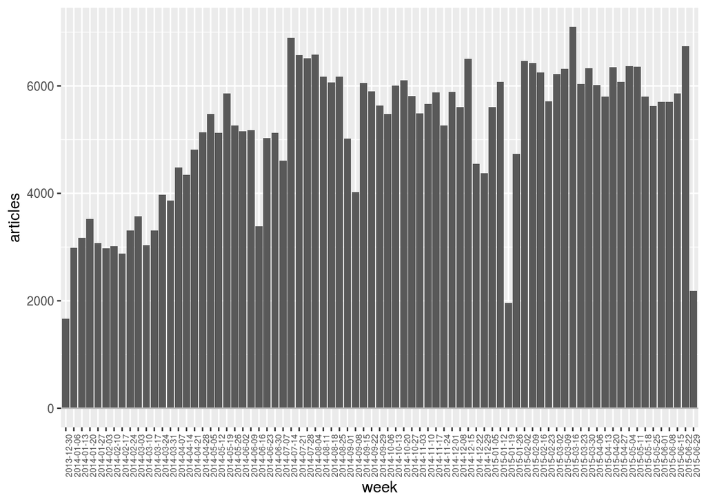

```r
geomedia %>%
    select.dim (week) %>%
    arrange.elm (week, name) %>%
    plot.var (articles) +
    theme (axis.text.x = element_text (angle = 90, size = 6))
```

Several plot types are available: `bar` (above), `line` (below), and `point`.

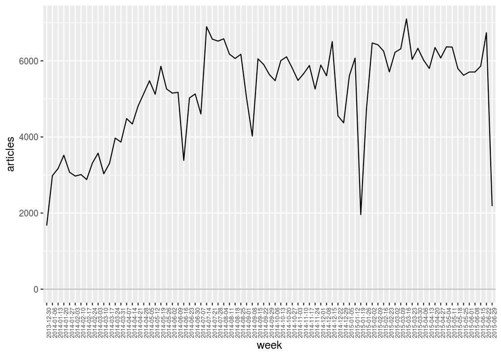

```r
geomedia %>%
    select.dim (week) %>%
    arrange.elm (week, name) %>%
    plot.var (articles, type = "line") +
    theme (axis.text.x = element_text (angle = 90, size = 6))
```

## Filtering elements with `filter.elm` and `top_n.elm`

Note that some observations in the plot above are surprisingly low. (They actually correspond to technical incidents during data collection.)

Function `top_n.elm` only keeps the elements of a dimension that have the highest (or the lowest) value according to a variable. We here plot the 10 weeks in the data that have the lowest number of published article (note the `-` in argument `n`).

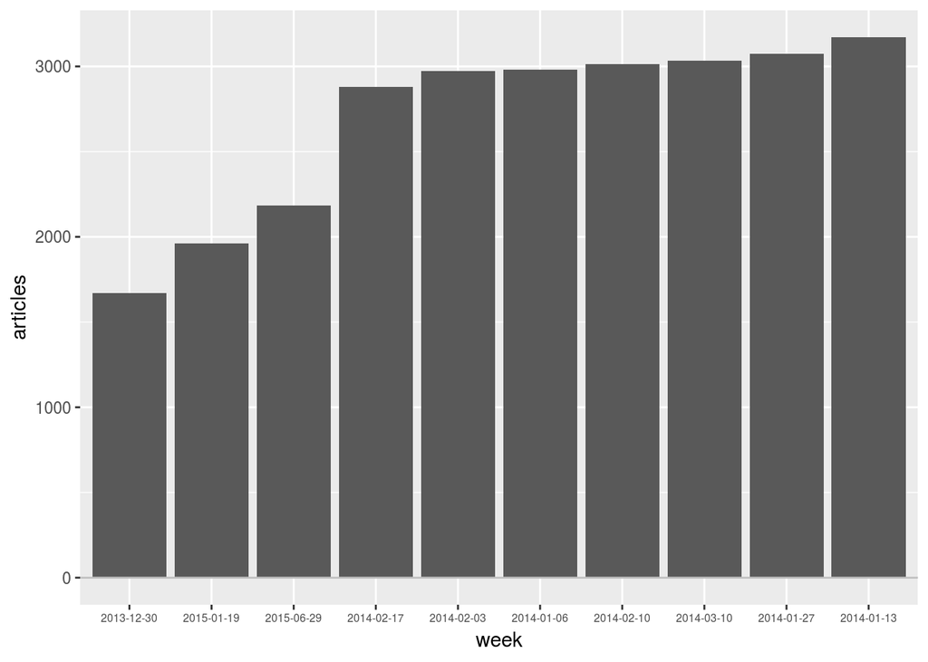

```r
geomedia %>%
    select.dim (week) %>%
    top_n.elm (week, articles, n = -10) %>%
    arrange.elm (week, articles) %>%
    plot.var (articles) +
    theme (axis.text.x = element_text (size = 6))
```

Function `filter.elm` only keeps the elements of a dimension that fit with some criteria expressed on variables. We can for example use it to remove such anomalous observations.

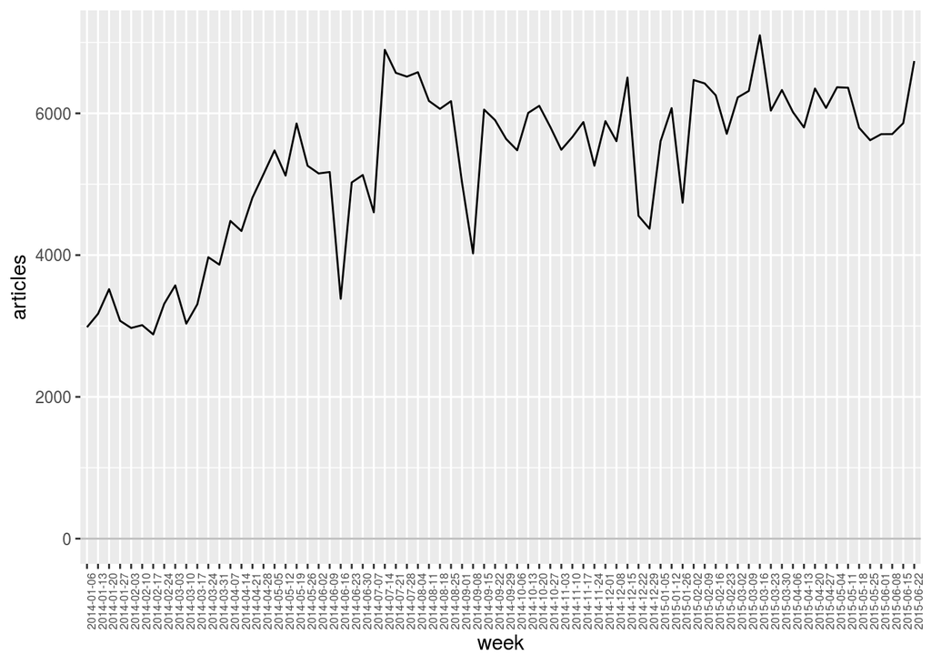

```r
geomedia %>%
    select.dim (week) %>%
    filter.elm (week, articles >= 2500) %>%
    arrange.elm (week, name) %>%
    plot.var (articles, type = "line") +
    theme (axis.text.x = element_text (angle = 90, size = 6))
```

## Other examples of use

Here are other examples of use of these simple operations, illustrated on the spatial dimension `country`.

One can plot the number of articles associated with the top 20 countries (arranged in a decreasing order).

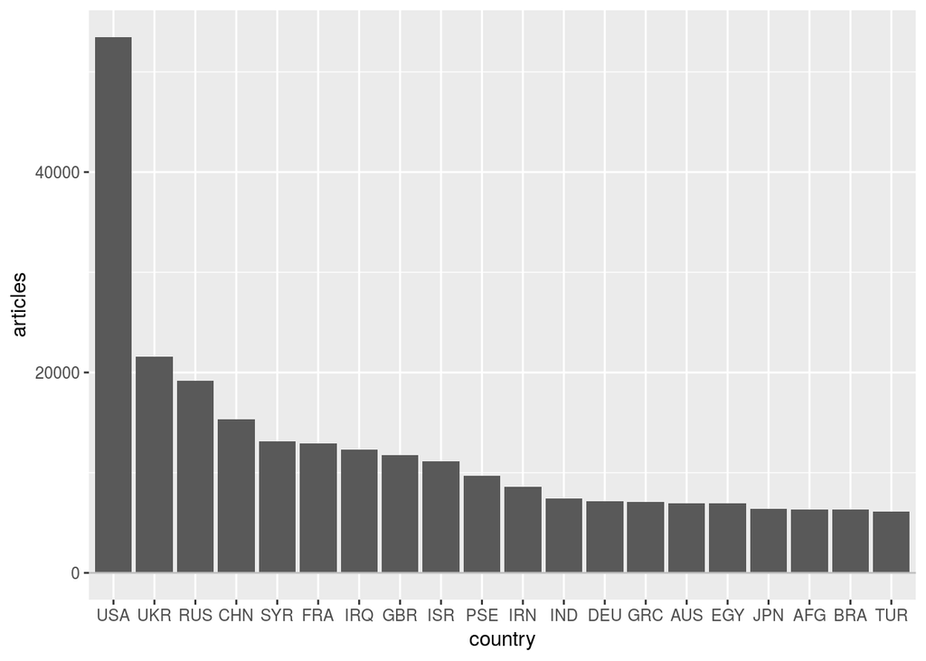

```r
geomedia %>%
    select.dim (country) %>%
    top_n.elm (country, articles, 20) %>%
    arrange.elm (country, desc (articles)) %>%
    plot.var (articles)
```

One can filter and arrange countries according to a given subset.

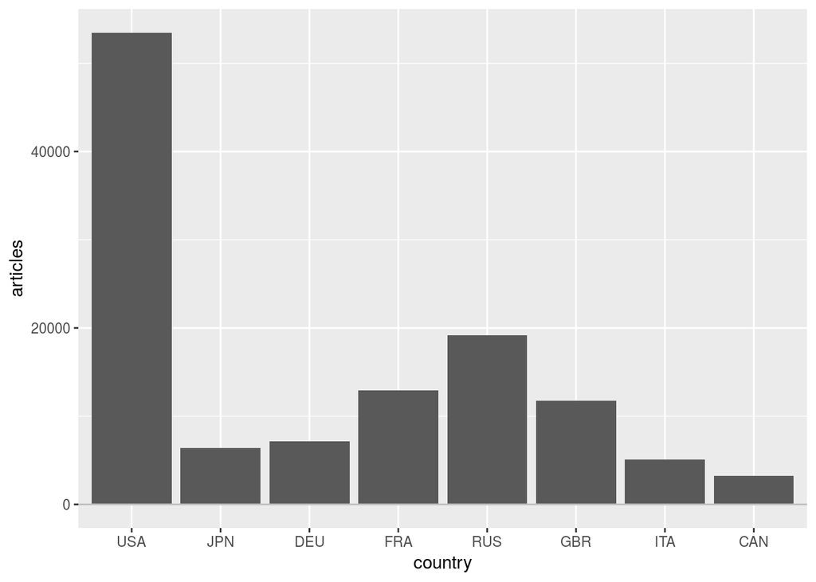

```r
G8 <- c ("USA", "JPN", "DEU", "FRA", "RUS", "GBR", "ITA", "CAN")
geomedia %>%
    select.dim (country) %>%
    filter.elm (country, name %in% G8) %>%
    arrange.elm (country, match (name, G8)) %>%
    plot.var (articles)
```

# Multidimensional Exploration

In this second section, we simultaneously deal with several dimensions. Multidimensional plotting of variables is then possible.

## Selecting two dimensions with `select.dim`

When selecting two dimensions (or more) with function `select.dim`, one ends up with a multidimensional representation of the corresponding variables. For example, in the code below, one selects dimensions `week` and `country` (in other words, dimension `media` is aggregated). Each observation hence gives the number of `articles` published during a given `week` and talking about a given `country`.

```r
geomedia %>%
    select.dim (week, country) %>%
    arrange.elm (country, name) %>%
    arrange.elm (week, name) %>%
    as.data.frame
```

```
## # A tibble: 11,051 x 3
##    week       country articles
##    <date>     <chr>      <dbl>
##  1 2013-12-30 AFG        22
##  2 2013-12-30 ARG         6
##  3 2013-12-30 AUS        29.5
##  4 2013-12-30 BEN         2
##  5 2013-12-30 BGD        30
##  6 2013-12-30 BGR         7.67
##  7 2013-12-30 BHS         2
##  8 2013-12-30 BLR         0.5
##  9 2013-12-30 BOL         2.5
## 10 2013-12-30 BRA        10.5
## # … with 11,041 more rows
```

## Plotting bidimensional variables with argument `sep.dim.names` of `plot.var`

In order to plot variable `articles` according to the two selected dimensions, one can use argument `sep.dim.names` of function `plot.var` to indicate which one of the two dimensions should be used to separate the data.

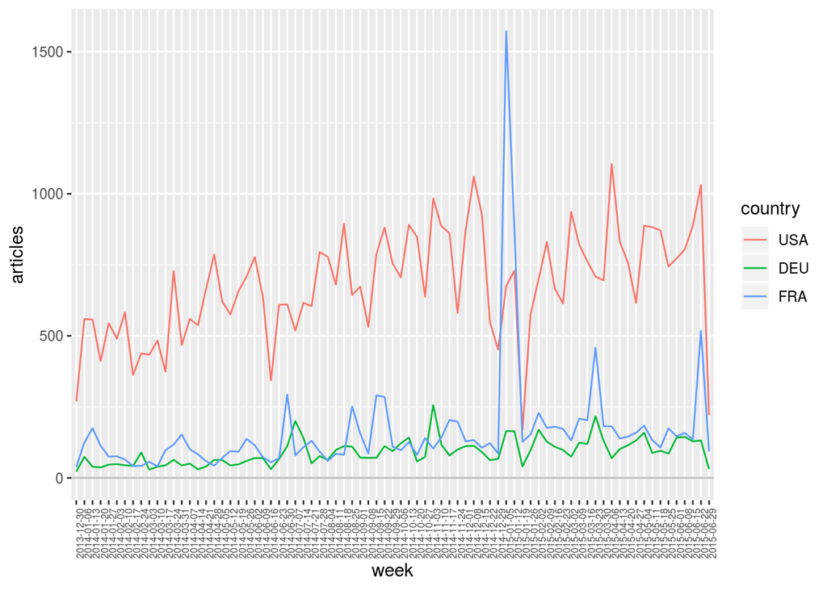

```r
geomedia %>%
    select.dim (week, country) %>%
    arrange.elm (week, name) %>%
    filter.elm (country, name %in% c ("USA", "FRA", "DEU")) %>%
    plot.var (articles, sep.dim.names = country, type = "line") +
    theme (axis.text.x = element_text (angle = 90, size = 6))
```

In this context, using a point-plot (instead of a line-plot) can be useful to separate a dimension with many elements. (Note that, below, we also use `filter.elm` on `week` to only plot data for year 2014.)

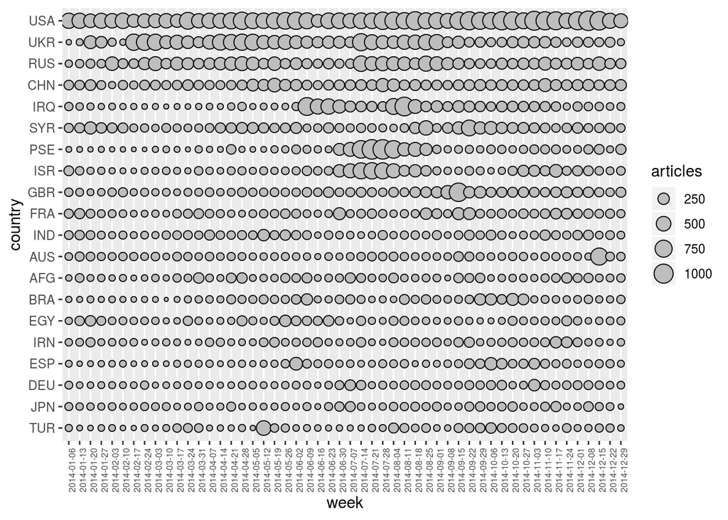

```r
geomedia %>%
    select.dim (week, country) %>%
    filter.elm (week, format (name, "%Y") == "2014") %>%
    arrange.elm (week, name) %>%
    top_n.elm (country, articles, 20) %>%
    arrange.elm (country, desc (articles)) %>%
    plot.var (articles, sep.dim.names = country, type = "point") +
    theme (axis.text.x = element_text (angle = 90, size = 6))
```

## Plotting multidimensional variables

It is also possible to separate the data according to several dimensions (with not so many elements) at the same time in order to plot multidimensional variables. For example, the plot below gives the temporal evolution of `articles` for 8 countries and 2 newspapers.

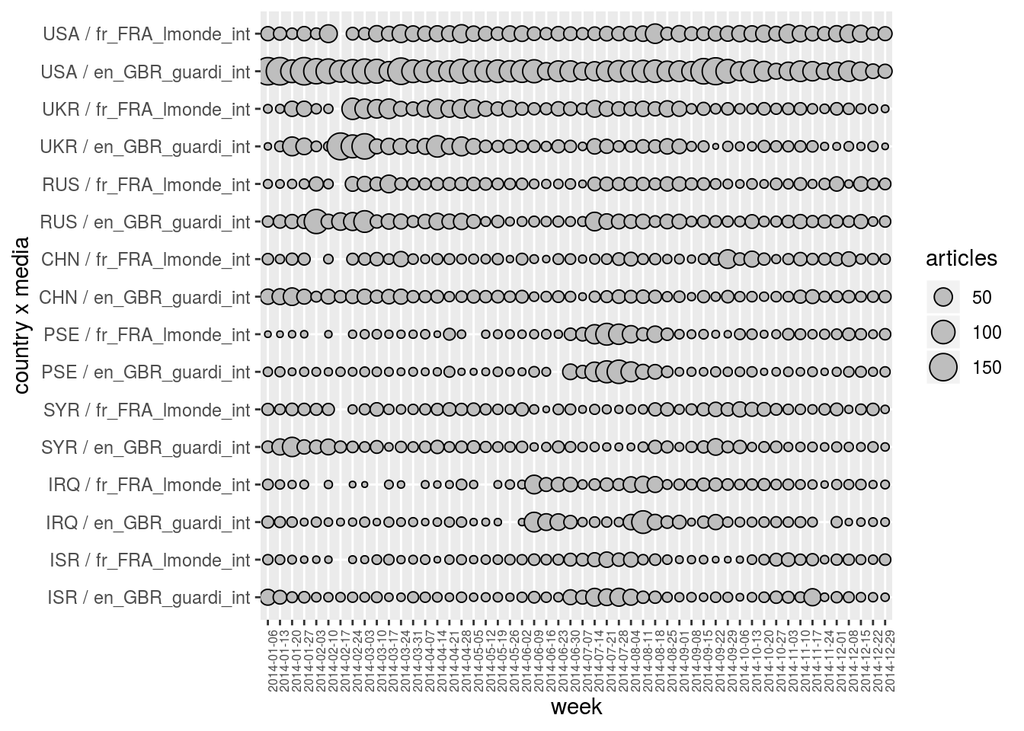

```r
geomedia %>%
    filter.elm (week, format (name, "%Y") == "2014") %>%
    arrange.elm (week, name) %>%
    top_n.elm (country, articles, 8) %>%
    arrange.elm (country, desc (articles)) %>%
    filter.elm (media, name %in% c ("fr_FRA_lmonde_int", "en_GBR_guardi_int")) %>%
    plot.var (articles, sep.dim.names = list (country, media), type = "point") +
    theme (axis.text.x = element_text (angle = 90, size = 6))
```

# Outlier Analysis

One of the tools that the `data.cube` library offers deals with the detection of statistical outliers in multidimensional data. In this context, variables are interpreted as multidimensional [contingency tables](https://en.wikipedia.org/wiki/Contingency_table) from which multiple marginal counts can be extracted (depending on the selected dimensions). These marginals then allow for the design of multiple models of the observed variables, from which significant deviations are then interpreted as outliers. In this part of the tutorial, we show how functions `compute.var.model` and `plot.outliers` allow for the computation of such models and the visualisation of the resulting deviations.

For more details regarding the formal ground of these functions, please refer to: *Audrey Wilmet and Robin Lamarche-Perrin. (2019). Multidimensional Outlier Detection in Temporal Interaction Networks.* [arXiv:1906.02541](https://arxiv.org/abs/1906.02541)

## First example: Bidimensional outliers

This first example focuses on the evolution over year 2014 of the number of articles citing the 5 following countries: USA, Russia, Spain, Italy, and Japan.

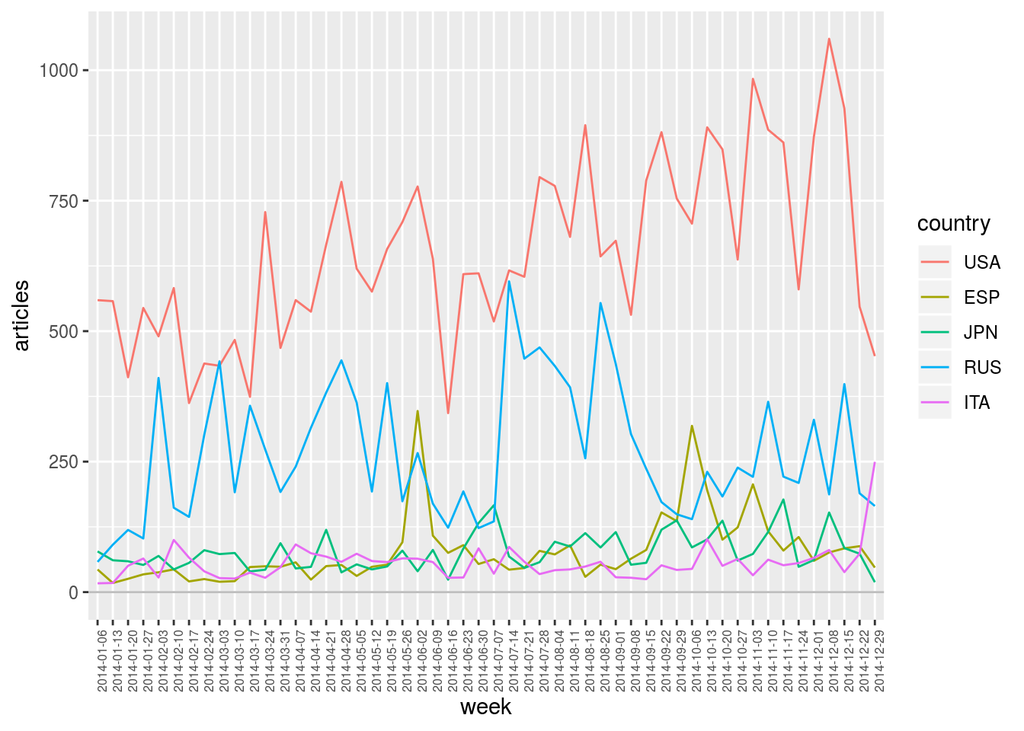

```r
geomedia_2014 <-
    geomedia %>%
    select.dim (week, country) %>%
    filter.elm (week, format (name, "%Y") == "2014") %>%
    arrange.elm (week, name)

selected_countries <- c ("USA", "RUS", "ESP", "ITA", "JPN")

geomedia_2014 %>%
    filter.elm (country, name %in% selected_countries) %>%
    plot.var (articles, sep.dim.names = country, type = "line") +
    theme (axis.text.x = element_text (angle = 90, size = 6))
```

### Taking into account the average number of articles per country

By plotting the distribution of these observations, one could define some king of “statistically expected” range of values and then identify outliers as unexpectedly high values.

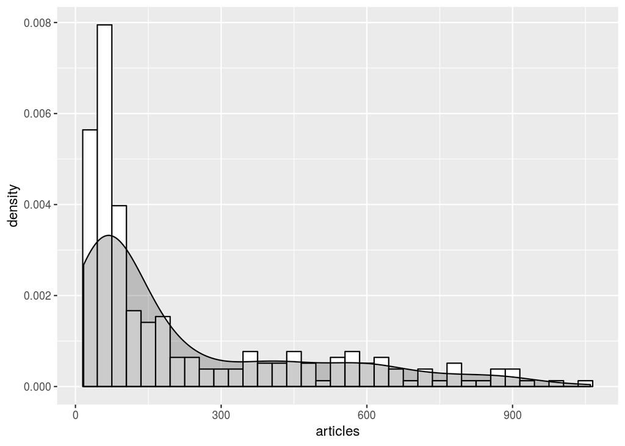

```r
geomedia_2014 %>%
    filter.elm (country, name %in% selected_countries) %>%
    as.data.frame %>%
    ggplot (aes (x = articles)) +
    geom_histogram (aes (y = ..density..), binwidth = 30, colour = "black", fill = "white") +
    geom_density (alpha = 0.2, fill = "black")
```

Yet, one could also consider that each of the five selected country have its own expected range of values, depending on its “average media coverage” (average number of articles per day).

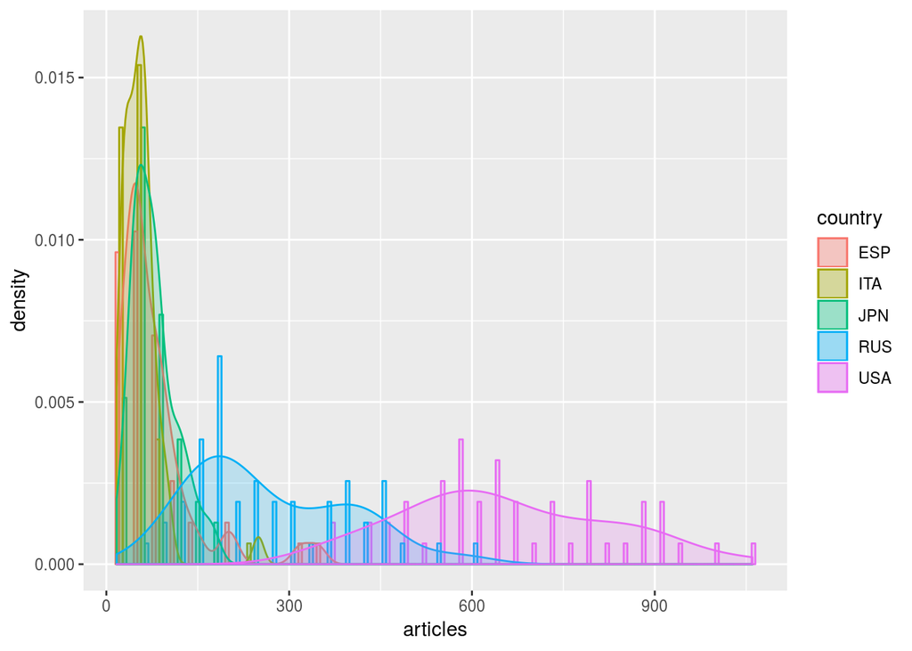

```r
geomedia_2014 %>%
    filter.elm (country, name %in% selected_countries) %>%
    as.data.frame %>%
    ggplot (aes (x = articles, color = country, fill = country)) +
    geom_histogram (aes (y = ..density..), binwidth = 30, alpha = 0.2, position = "dodge") +
    geom_density (alpha = 0.2)
```

Hence, one could take into account these averaged values as an additional information to identify more specific outliers.

```r
geomedia_2014 %>%
    filter.elm (country, name %in% selected_countries) %>%
    compute.var.model (articles (week * country) ~ articles (country)) %>%
    summary
```

```
## Computing model: articles (week * country) ~ articles (country) * NULL (week)
```

[output not shown]

```
## Computing model: articles (week * country) ~ articles (country) * NULL (week)
```

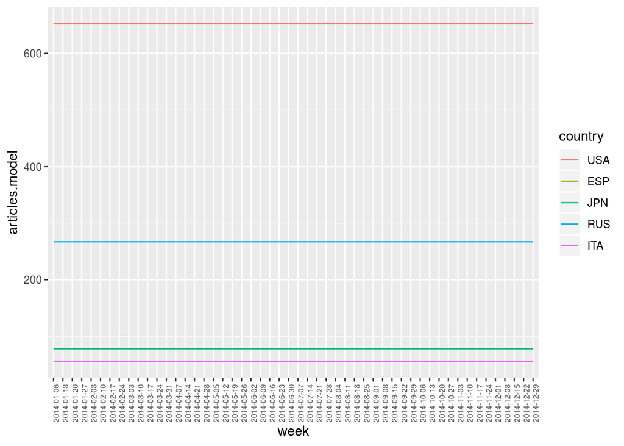

```r
geomedia_2014 %>%
    compute.var.model (articles (week * country) ~ articles (country)) %>%
    filter.elm (country, name %in% selected_countries) %>%
    plot.var (articles.model, sep.dim.names = country, type = "line") +
    theme (axis.text.x = element_text (angle = 90, size = 6))
```

```
## Computing model: articles (week * country) ~ articles (country) * NULL (week)
```

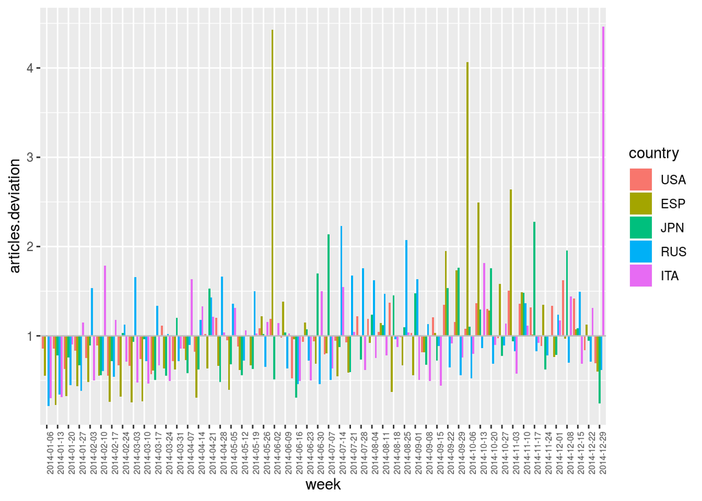

```r
geomedia_2014 %>%
    compute.var.model (articles (week * country) ~ articles (country)) %>%
    filter.elm (country, name %in% selected_countries) %>%
    plot.var (articles.deviation, sep.dim.names = country, type = "bar") +
    theme (axis.text.x = element_text (angle = 90, size = 6))
```

### Also taking into account the average number of articles per day

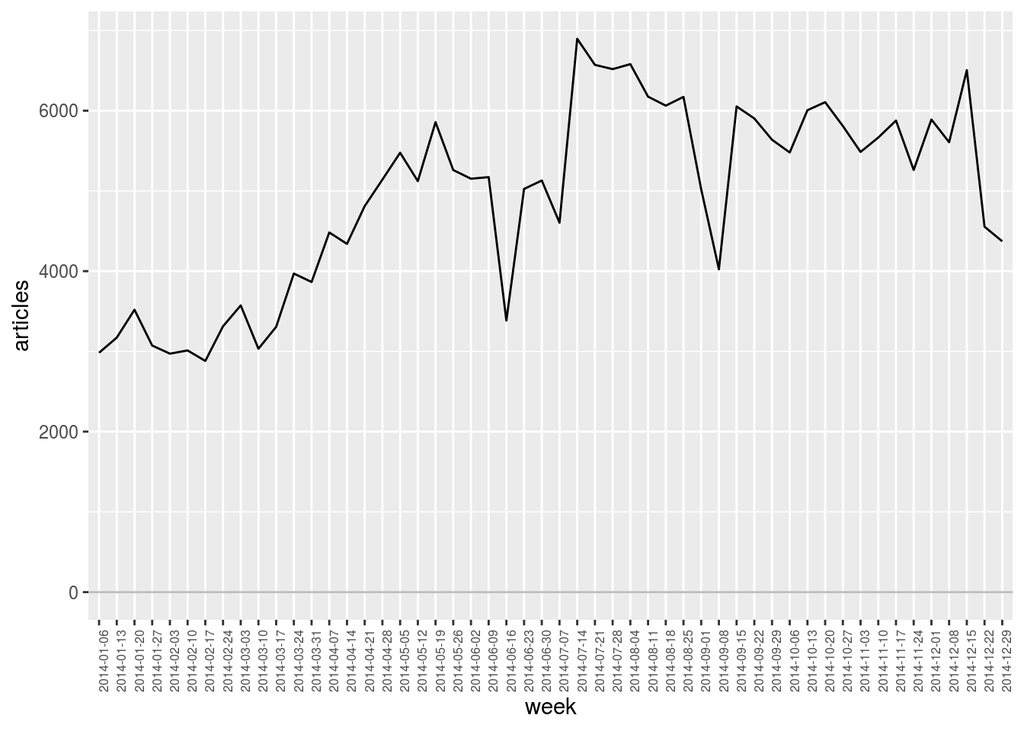

```r
geomedia_2014 %>%
    select.dim (week) %>%
    plot.var (articles, type = "line") +
    theme (axis.text.x = element_text (angle = 90, size = 6))
```

```
## Computing model: articles (week * country) ~ articles (week) * articles (country)
```

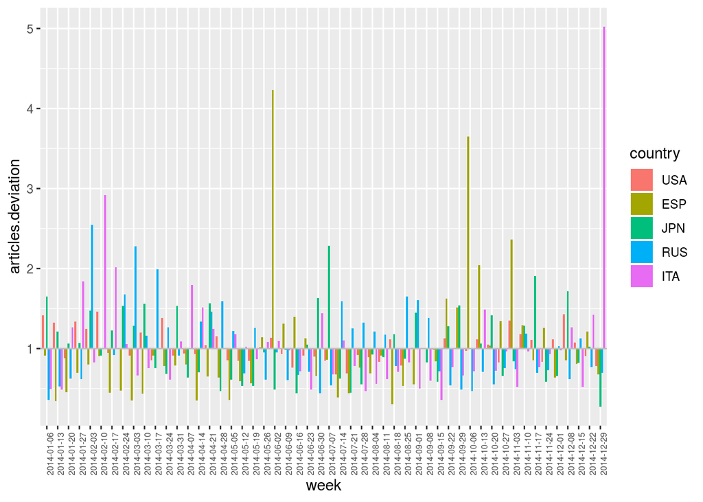

```r
geomedia_2014 %>%
    compute.var.model (articles (week * country) ~ articles (week) * articles (country)) %>%
    filter.elm (country, name %in% selected_countries) %>%
    plot.var (articles.deviation, sep.dim.names = country, type = "bar") +
    theme (axis.text.x = element_text (angle = 90, size = 6))
```